# Analyzing the achievement gap between Black and White students in Philadelphia School Districts

## Samuel Barksdale, Fadil Ibrahim

## Introduction

#### The purpose of this project is to analyze the achievement gap between white and black students that are juniors in High School in the School District of Philadelphia, our home district.

#### Through this tutorial we aim to determine whether there is a gap present, as well as how wide it is, using performance levels obtained from the results of the English Language Arts (ELA), Mathematics, and Science portions of the Pennsylvania System of School Assessment (PSSA) exam. We use this exam as well as the Algebra I, Biology, and Literature exams specifically for 11th graders to assess the disparity in academic performance.

### Data collection:

We'll first start by collecting data from the school district's website from the District Performance Office (https://www.philasd.org/performance/programsservices/open-data/pssakeystone/)

To get a broad range of data, we go back 5 years starting at the 2013-2014 school year results. The results for each year contain plenty of data including schools, categories of classification, the number of students tested, as well as how many scored either:

1. Below Basic
2. Basic
3. Proficient
4. Advanced
5. Proficient + Advanced

...and the percentages for the corresponding counts.

```python
import pandas as pd
import numpy as np
import matplotlib.pyplot as plt
from sklearn import linear_model
from statistics import mean

df18 = pd.read_excel('2018 PSSA Keystone Actual (School_S).xlsx')
ex17 = pd.ExcelFile('2017 PSSA Keystone Actual (School_S).xlsx')
ex16 = pd.ExcelFile('2016 PSSA Keystone Actual (School_S).xlsx')
ex15 = pd.ExcelFile('2015 PSSA Keystone Actual (School_S).xlsx')
ex14 = pd.ExcelFile('2014 PSSA Keystone Actual (School_S).xlsx')
```

### Data Processing:

The next step in the procedure is to process the data we have obtained and make it more organized and tidy. We do this, so that the sets of data for each year are uniform and easy to work with when it comes time to analyze it.

To read more on the subject of tidy data: http://www.jeannicholashould.com/tidy-data-in-python.html

We first check out the first few rows of the 2017 data, which is similar to the years before it, to see how we can organize it.

The data we want is specific to race so we only want to include this set. For the years 2014 to 2017, there are several sheets so we isolate the one we need, Ethnicity.

```python
#Check out the first few rows of the 2017 data
ex17.parse(sheet_name='Ethnicity', skiprows=0).head(10)
```

|  | School District of Philadelphia | Unnamed: 1 | Unnamed: 2 | Unnamed: 3 | Unnamed: 4 | Unnamed: 5 | Unnamed: 6 | Unnamed: 7 | Unnamed: 8 | Unnamed: 9 | Unnamed: 10 | Unnamed: 11 | Unnamed: 12 | Unnamed: 13 | Unnamed: 14 | Unnamed: 15 | Unnamed: 16 | Unnamed: 17 |
| --- | --- | --- | --- | --- | --- | --- | --- | --- | --- | --- | --- | --- | --- | --- | --- | --- | --- | --- |
| NaN | Results on the Pennsylvania State 2017 PSSA an... | NaN | NaN | NaN | NaN | NaN | NaN | NaN | NaN | NaN | NaN | NaN | NaN | NaN | NaN | NaN | NaN | NaN |
| NaN | School Summary | NaN | NaN | NaN | NaN | NaN | NaN | NaN | NaN | NaN | NaN | NaN | NaN | NaN | NaN | NaN | NaN | NaN |
| NaN | Results for Ethnicity | NaN | NaN | NaN | NaN | NaN | NaN | NaN | NaN | NaN | NaN | NaN | NaN | NaN | NaN | NaN | NaN | NaN |
| NaN | NaN | NaN | NaN | NaN | NaN | NaN | NaN | NaN | NaN | NaN | NaN | NaN | NaN | NaN | NaN | NaN | NaN | NaN |
| NaN | NaN | NaN | NaN | NaN | NaN | NaN | NaN | NaN | Level 1\n(Below Basic) | NaN | Level 2\n(Basic) | NaN | Level 3\n(Proficient) | NaN | Level 4\n(Advanced) | NaN | Levels 3+4\n(Proficient + Advanced) | NaN |
| NaN | Test Name | Subject | School\nCode | School Name | Learning Network | Grade | Category | Number\nTested | Count # | Percent % | Count # | Percent % | Count # | Percent % | Count # | Percent % | Count # | Percent % |
| NaN | Keystone | Algebra 1 | 609 | A. Philip Randolph Career and Technical High S... | NEIGHBORHOOD NETWORK 4 | 11 | Black/African American (not Hispanic) | 117 | 52 | 0.444444 | 54 | 0.461538 | 10 | 0.0854701 | 1 | 0.00854701 | 11 | 0.0940171 |
| NaN | Keystone | Algebra 1 | 609 | A. Philip Randolph Career and Technical High S... | NEIGHBORHOOD NETWORK 4 | 11 | Hispanic (any race) | 4 | s | s | s | s | s | s | s | s | s | s |
| NaN | Keystone | Algebra 1 | 609 | A. Philip Randolph Career and Technical High S... | NEIGHBORHOOD NETWORK 4 | 11 | Multi-Racial/Two or more races (not Hispanic) | 1 | s | s | s | s | s | s | s | s | s | s |
| NaN | Keystone | Algebra 1 | 609 | A. Philip Randolph Career and Technical High S... | NEIGHBORHOOD NETWORK 4 | 11 | White (not Hispanic) | 3 | s | s | s | s | s | s | s | s | s | s |

We find that the column headers are in the 6th row and the body of the data begins in the 7th row, so we want to adjust that by using 'skiprows=6' on the data from 2014 to 2017.

In the years 2014-2017, we parse the data to include just the Ethnicity sheet. We rename columns that aren't properly formatted including Category to Group, Number\nTested to Number Tested, Percent % to Percent Below Basic, Percent %.1 to Percent Basic, Percent %.2 to Percent Proficient, Percent %.3 to Percent Advanced, and Percent %.4 to Percent Prof/adv.

Because we are solely looking for data connecting race with performance as it pertains to the entire school district, we get rid of certain columns including school name, school id number or code, the counts of each performance level (leaving just the percentage columns), and what learning network the students came from.

```python
#drop irrelevant columns in 2018
df18 = df18.drop(columns=['SRC School ID','School Name', 'Category', 'Learning Network', 'Count Below Basic', 'Count Basic', 'Count Proficient', 'Count Advanced', 'Count Prof/Adv'])

#reformat data for years 2014-2017
df17 = ex17.parse(sheet_name='Ethnicity', skiprows=6)
df17 = df17.rename(columns={'Category': 'Group','Unnamed: 0': 'one', 'Number\nTested': 'Number Tested', 'Percent %': 'Percent Below Basic', 'Percent %.1': 'Percent Basic', 'Percent %.2': 'Percent Proficient', 'Percent %.3': 'Percent Advanced', 'Percent %.4': 'Percent Prof/Adv'})
df17 = df17.drop(columns=['one', 'Count #', 'Count #.1', 'Count #.2', 'Count #.3', 'Count #.4', 'School\nCode', 'School Name', 'Learning Network'])

df16 = ex16.parse(sheet_name='Ethnicity', skiprows=6)
df16 = df16.rename(columns={'Category': 'Group','Unnamed: 0': 'one', 'Unnamed: 19': 'two', 'Number\nTested': 'Number Tested', 'Percent %': 'Percent Below Basic', 'Percent %.1': 'Percent Basic', 'Percent %.2': 'Percent Proficient', 'Percent %.3': 'Percent Advanced', 'Percent %.4': 'Percent Prof/Adv'})
df16 = df16.drop(columns=['one', 'two', 'Count #', 'Count #.1', 'Count #.2', 'Count #.3', 'Count #.4', 'School\nCode', 'School Name', 'Learning Network'])

df15 = ex15.parse(sheet_name='Ethnicity', skiprows=6)
df15 = df15.rename(columns={'Category': 'Group','Unnamed: 0': 'one', 'Unnamed: 19': 'two', 'Number\nTested': 'Number Tested', 'Percent %': 'Percent Below Basic', 'Percent %.1': 'Percent Basic', 'Percent %.2': 'Percent Proficient', 'Percent %.3': 'Percent Advanced', 'Percent %.4': 'Percent Prof/Adv'})
df15 = df15.drop(columns=['one', 'two', 'Count #', 'Count #.1', 'Count #.2', 'Count #.3', 'Count #.4', 'School\nCode', 'School Name', 'Learning Network'])

df14 = ex14.parse(sheet_name='Ethnicity', skiprows=6)
df14 = df14.rename(columns={'Category': 'Group','Unnamed: 0': 'one', 'Unnamed: 18': 'two', 'Number\nTested': 'Number Tested', 'Percent %': 'Percent Below Basic', 'Percent %.1': 'Percent Basic', 'Percent %.2': 'Percent Proficient', 'Percent %.3': 'Percent Advanced', 'Percent %.4': 'Percent Prof/Adv'})
df14 = df14.drop(columns=['one', 'two', 'Count #', 'Count #.1', 'Count #.2', 'Count #.3', 'Count #.4', 'School\nCode', 'School Name'])
```

The purpose of our tutorial is to analyze race as it relates to academic performance levels in the Philadelphia school district, so we set certain booleans to only include the rows that count "Black/African American (not Hispanic" students as well as "White (not Hispanic)" students.

```python
#only look at students that fall under the desired race categories
black18 = df18['Group'] == "Black/African American (not Hispanic)"
white18 = df18['Group'] == "White (not Hispanic)"

black17 = df17['Group'] == "Black/African American (not Hispanic)"
white17 = df17['Group'] == "White (not Hispanic)"

black16 = df16['Group'] == "Black/African American (not Hispanic)"
white16 = df16['Group'] == "White (not Hispanic)"

black15 = df15['Group'] == "Black/African American (not Hispanic)"
white15 = df15['Group'] == "White (not Hispanic)"

black14 = df14['Group'] == "Black/African American (not Hispanic)"
white14 = df14['Group'] == "White (not Hispanic)"

temp18 = df18[black18 | white18]
temp17 = df17[black17 | white17]
temp16 = df16[black16 | white16]
temp15 = df15[black15 | white15]
temp14 = df14[black14 | white14]
```

Since our focus is on juniors in high school, we want to finish the tidying of our data by adding one more boolean value. This value checks whether a row is classified as pertaining to 11th graders or not. If it is, then we want to include it in our dataframe which already accounted for race.

So after this step, our data has been cleaned up and organized by dropping unnecessary columns, renaming columns for consistent dataframes among the years, and reshaping the data to only include the rows that are needed for our analysis.

```python
junior18 = temp18['Grade'] == "11"

junior17 = temp17['Grade'] == 11

junior16 = temp16['Grade'] == 11

junior15 = temp15['Grade'] == 11

junior14 = temp14['Grade'] == 11



#set new dataframes to include only the desired data
df18 = temp18[junior18]
df17 = temp17[junior17]
df16 = temp16[junior16]
df15 = temp15[junior15]
df14 = temp14[junior14]


#checking to make sure that the data for each year is uniform
#print(df18.head(20))
#print(df17.head(20))
#print(df16.head(20))
#print(df15.head(20))
#print(df14.head(20))
index = np.arange(2)
```

# Exploratory Analysis and Data Visualization

Now that we have our data in a way that we can easily read from it, we can start analyzing the data. The first thing that we are going to look at is the year 2018. We were curious of whether or not the achievement gap existed in the most recent year.

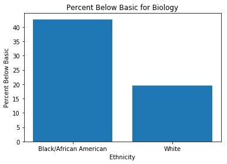

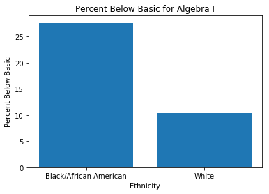

```
The Average for Black/African American students in Biology is 42.730624999999996
The Average for White students in Biology is 19.538235294117648
The Average for Black/African American students in Algebra I is 27.613333333333333
The Average for White students in Algebra I is 10.408823529411764
```

```python
black_bio_data = []
white_bio_data = []
#test = df18['Subject']
#print(test)


for i, x in df18.iterrows():
    if df18.at[i, 'Group'] == "Black/African American (not Hispanic)":

        if df18.at[i, 'Percent Below Basic'] != 's' and df18.at[i, 'Subject'] == 'Biology':
            black_bio_data.append(df18.at[i, 'Percent Below Basic'])

for i, x in df18.iterrows():
    if df18.at[i, 'Group'] == "White (not Hispanic)":

        if df18.at[i, 'Percent Below Basic'] != 's' and df18.at[i, 'Subject'] == 'Biology':
            white_bio_data.append(df18.at[i, 'Percent Below Basic'])

black_bio_data = list(map(float, black_bio_data))
white_bio_data = list(map(float, white_bio_data))


black_avg = mean(black_bio_data)
white_avg = mean(white_bio_data)

b_bio_avg = black_avg
w_bio_avg = white_avg

data = [black_avg, white_avg]
label = ['Black/African American', 'White']
plt.bar(index, data)
plt.xlabel('Ethnicity', fontsize=10)
plt.ylabel('Percent Below Basic', fontsize=10)
plt.xticks(index, label, fontsize=10)
plt.title('Percent Below Basic for Biology')
plt.show()


black_algebra_data = []
white_algebra_data = []
#test = df18['Subject']
#print(test)


for i, x in df18.iterrows():
    if df18.at[i, 'Group'] == "Black/African American (not Hispanic)":

        if df18.at[i, 'Percent Below Basic'] != 's' and df18.at[i, 'Subject'] == 'Algebra I':
            black_algebra_data.append(df18.at[i, 'Percent Below Basic'])

for i, x in df18.iterrows():
    if df18.at[i, 'Group'] == "White (not Hispanic)":

        if df18.at[i, 'Percent Below Basic'] != 's' and df18.at[i, 'Subject'] == 'Algebra I':
            white_algebra_data.append(df18.at[i, 'Percent Below Basic'])

black_algebra_data = list(map(float, black_algebra_data))
white_algebra_data = list(map(float, white_algebra_data))


black_avg = mean(black_algebra_data)
white_avg = mean(white_algebra_data)

b_alg_avg = black_avg
w_alg_avg = white_avg

data = [black_avg, white_avg]
label = ['Black/African American', 'White']
plt.bar(index, data)
plt.xlabel('Ethnicity', fontsize=10)
plt.ylabel('Percent Below Basic', fontsize=10)
plt.xticks(index, label, fontsize=10)
plt.title('Percent Below Basic for Algebra I')
plt.show()

print("The Average for Black/African American students in Biology is " + str(b_bio_avg))
print("The Average for White students in Biology is " + str(w_bio_avg))
print("The Average for Black/African American students in Algebra I is " + str(b_alg_avg))
print("The Average for White students in Algebra I is " + str(w_alg_avg))
```

# Initial Findings

Hmm, It does appear that a much higher percent of African American students received scores of Below Basic than White students on the Biology portion. Approximately ~23% gap exists in this area.

The Algebra I test also shows a similar trend. African American Students are significantly higher than White students. The gap is not as large however. The gap that exists here is only approximately 17%.

The next thing to look at is how Black students compare to White students in the placement of Advanced test scores.

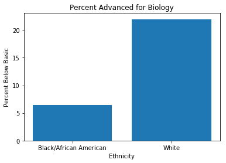

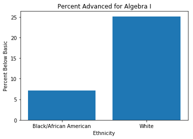

```
The Average for Black/African American students in Biology is 6.434166666666667
The Average for White students in Biology is 21.96470588235294
The Average for Black/African American students in Algebra I is 7.132916666666667
The Average for White students in Algebra I is 25.12764705882353
```

```python
black_bio_data = []
white_bio_data = []
#test = df18['Subject']
#print(test)


for i, x in df18.iterrows():
    if df18.at[i, 'Group'] == "Black/African American (not Hispanic)":

        if df18.at[i, 'Percent Advanced'] != 's' and df18.at[i, 'Subject'] == 'Biology':
            black_bio_data.append(df18.at[i, 'Percent Advanced'])

for i, x in df18.iterrows():
    if df18.at[i, 'Group'] == "White (not Hispanic)":

        if df18.at[i, 'Percent Advanced'] != 's' and df18.at[i, 'Subject'] == 'Biology':
            white_bio_data.append(df18.at[i, 'Percent Advanced'])

black_bio_data = list(map(float, black_bio_data))
white_bio_data = list(map(float, white_bio_data))


black_avg = mean(black_bio_data)
white_avg = mean(white_bio_data)

b_bio_avg = black_avg
w_bio_avg = white_avg

data = [black_avg, white_avg]
label = ['Black/African American', 'White']
plt.bar(index, data)
plt.xlabel('Ethnicity', fontsize=10)
plt.ylabel('Percent Below Basic', fontsize=10)
plt.xticks(index, label, fontsize=10)
plt.title('Percent Advanced for Biology')
plt.show()


black_algebra_data = []
white_algebra_data = []
#test = df18['Subject']
#print(test)


for i, x in df18.iterrows():
    if df18.at[i, 'Group'] == "Black/African American (not Hispanic)":

        if df18.at[i, 'Percent Advanced'] != 's' and df18.at[i, 'Subject'] == 'Algebra I':
            black_algebra_data.append(df18.at[i, 'Percent Advanced'])

for i, x in df18.iterrows():
    if df18.at[i, 'Group'] == "White (not Hispanic)":

        if df18.at[i, 'Percent Advanced'] != 's' and df18.at[i, 'Subject'] == 'Algebra I':
            white_algebra_data.append(df18.at[i, 'Percent Advanced'])

black_algebra_data = list(map(float, black_algebra_data))
white_algebra_data = list(map(float, white_algebra_data))


black_avg = mean(black_algebra_data)
white_avg = mean(white_algebra_data)

b_alg_avg = black_avg
w_alg_avg = white_avg


data = [black_avg, white_avg]
label = ['Black/African American', 'White']
plt.bar(index, data)
plt.xlabel('Ethnicity', fontsize=10)
plt.ylabel('Percent Below Basic', fontsize=10)
plt.xticks(index, label, fontsize=10)
plt.title('Percent Advanced for Algebra I')
plt.show()

print("The Average for Black/African American students in Biology is " + str(b_bio_avg))
print("The Average for White students in Biology is " + str(w_bio_avg))
print("The Average for Black/African American students in Algebra I is " + str(b_alg_avg))
print("The Average for White students in Algebra I is " + str(w_alg_avg))
```

# Findings

Our findings here definitely reflect what can be assumed from the previous discovery. Black students receive scores of Advanced at a much lower percent than White students in both Algebra and Biology categories. The gap in Biology is approximately 16% and the gap in Algebra I is approximately 18%

This discovery has led us to wanting to look into the trend that has existed over the past 5 years.

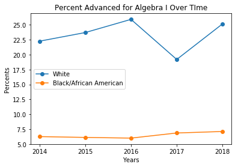

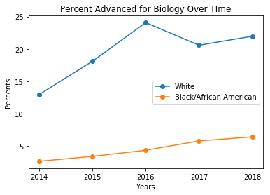

```python
black_algebra_data_18 = []
white_algebra_data_18 = []

black_algebra_data_17 = []
white_algebra_data_17 = []

black_algebra_data_16 = []
white_algebra_data_16 = []

black_algebra_data_15 = []
white_algebra_data_15 = []

black_algebra_data_14 = []
white_algebra_data_14 = []


#2018 Scores
for i, x in df18.iterrows():
    if df18.at[i, 'Group'] == "Black/African American (not Hispanic)":

        if df18.at[i, 'Percent Advanced'] != 's' and df18.at[i, 'Subject'] == 'Algebra I':
            black_algebra_data_18.append(df18.at[i, 'Percent Advanced'])

for i, x in df18.iterrows():
    if df18.at[i, 'Group'] == "White (not Hispanic)":

        if df18.at[i, 'Percent Advanced'] != 's' and df18.at[i, 'Subject'] == 'Algebra I':
            white_algebra_data_18.append(df18.at[i, 'Percent Advanced'])

#2017 Scores
for i, x in df17.iterrows():
    if df17.at[i, 'Group'] == "Black/African American (not Hispanic)":

        if df17.at[i, 'Percent Advanced'] != 's' and df17.at[i, 'Subject'] == 'Algebra 1':
            black_algebra_data_17.append(df17.at[i, 'Percent Advanced'])

for i, x in df17.iterrows():
    if df17.at[i, 'Group'] == "White (not Hispanic)":

        if df17.at[i, 'Percent Advanced'] != 's' and df17.at[i, 'Subject'] == 'Algebra 1':
            white_algebra_data_17.append(df17.at[i, 'Percent Advanced'])

#2016 Scores
for i, x in df16.iterrows():
    if df16.at[i, 'Group'] == "Black/African American (not Hispanic)":

        if df16.at[i, 'Percent Advanced'] != 's' and df16.at[i, 'Subject'] == 'Algebra I':
            black_algebra_data_16.append(df16.at[i, 'Percent Advanced'])

for i, x in df16.iterrows():
    if df16.at[i, 'Group'] == "White (not Hispanic)":

        if df16.at[i, 'Percent Advanced'] != 's' and df16.at[i, 'Subject'] == 'Algebra I':
            white_algebra_data_16.append(df16.at[i, 'Percent Advanced'])

#2015 Scores
for i, x in df15.iterrows():
    if df15.at[i, 'Group'] == "Black/African American (not Hispanic)":

        if df15.at[i, 'Percent Advanced'] != 's' and df15.at[i, 'Subject'] == 'Algebra I':
            black_algebra_data_15.append(df15.at[i, 'Percent Advanced'])

for i, x in df15.iterrows():
    if df15.at[i, 'Group'] == "White (not Hispanic)":

        if df15.at[i, 'Percent Advanced'] != 's' and df15.at[i, 'Subject'] == 'Algebra I':
            white_algebra_data_15.append(df15.at[i, 'Percent Advanced'])

#2014 Scores
for i, x in df14.iterrows():
    if df14.at[i, 'Group'] == "Black/African American (not Hispanic)":

        if df14.at[i, 'Percent Advanced'] != 's' and df14.at[i, 'Subject'] == 'Algebra 1':
            black_algebra_data_14.append(df14.at[i, 'Percent Advanced'])

for i, x in df14.iterrows():
    if df14.at[i, 'Group'] == "White (not Hispanic)":

        if df14.at[i, 'Percent Advanced'] != 's' and df14.at[i, 'Subject'] == 'Algebra 1':
            white_algebra_data_14.append(df14.at[i, 'Percent Advanced'])



black_algebra_data_18 = list(map(float, black_algebra_data_18))
white_algebra_data_18 = list(map(float, white_algebra_data_18))

black_algebra_data_17 = list(map(float, black_algebra_data_17))
white_algebra_data_17 = list(map(float, white_algebra_data_17))

black_algebra_data_17 = [x * 100 for x in black_algebra_data_17]
white_algebra_data_17 = [x * 100 for x in white_algebra_data_17]

black_algebra_data_16 = list(map(float, black_algebra_data_16))
white_algebra_data_16 = list(map(float, white_algebra_data_16))

black_algebra_data_16 = [x * 100 for x in black_algebra_data_16]
white_algebra_data_16 = [x * 100 for x in white_algebra_data_16]

black_algebra_data_15 = list(map(float, black_algebra_data_15))
white_algebra_data_15 = list(map(float, white_algebra_data_15))

black_algebra_data_15 = [x * 100 for x in black_algebra_data_15]
white_algebra_data_15 = [x * 100 for x in white_algebra_data_15]

black_algebra_data_14 = list(map(float, black_algebra_data_14))
white_algebra_data_14 = list(map(float, white_algebra_data_14))

black_algebra_data_14 = [x * 100 for x in black_algebra_data_14]
white_algebra_data_14 = [x * 100 for x in white_algebra_data_14]

black_avg_18 = mean(black_algebra_data_18)
white_avg_18 = mean(white_algebra_data_18)

black_avg_17 = mean(black_algebra_data_17)
white_avg_17 = mean(white_algebra_data_17)

black_avg_16 = mean(black_algebra_data_16)
white_avg_16 = mean(white_algebra_data_16)

black_avg_15 = mean(black_algebra_data_15)
white_avg_15 = mean(white_algebra_data_15)

black_avg_14 = mean(black_algebra_data_14)
white_avg_14 = mean(white_algebra_data_14)


white_data = [white_avg_14, white_avg_15, white_avg_16, white_avg_17, white_avg_18]
black_data = [black_avg_14, black_avg_15, black_avg_16, black_avg_17, black_avg_18]
black_ml_data_alg = black_data
white_ml_data_alg = white_data
x = np.arange(5)
plt.plot(x, white_data, '-o', label='White')
plt.plot(x, black_data, '-o', label='Black/African American')
plt.xticks(x, [2014, 2015, 2016, 2017, 2018])
plt.xlabel('Years')
plt.ylabel('Percents')
plt.title('Percent Advanced for Algebra I Over TIme')
plt.legend(loc='center left')
plt.show()

black_bio_data_18 = []
white_bio_data_18 = []

black_bio_data_17 = []
white_bio_data_17 = []

black_bio_data_16 = []
white_bio_data_16 = []

black_bio_data_15 = []
white_bio_data_15 = []

black_bio_data_14 = []
white_bio_data_14 = []


#2018 Scores
for i, x in df18.iterrows():
    if df18.at[i, 'Group'] == "Black/African American (not Hispanic)":

        if df18.at[i, 'Percent Advanced'] != 's' and df18.at[i, 'Subject'] == 'Biology':
            black_bio_data_18.append(df18.at[i, 'Percent Advanced'])

for i, x in df18.iterrows():
    if df18.at[i, 'Group'] == "White (not Hispanic)":

        if df18.at[i, 'Percent Advanced'] != 's' and df18.at[i, 'Subject'] == 'Biology':
            white_bio_data_18.append(df18.at[i, 'Percent Advanced'])

#2017 Scores
for i, x in df17.iterrows():
    if df17.at[i, 'Group'] == "Black/African American (not Hispanic)":

        if df17.at[i, 'Percent Advanced'] != 's' and df17.at[i, 'Subject'] == 'Biology':
            black_bio_data_17.append(df17.at[i, 'Percent Advanced'])

for i, x in df17.iterrows():
    if df17.at[i, 'Group'] == "White (not Hispanic)":

        if df17.at[i, 'Percent Advanced'] != 's' and df17.at[i, 'Subject'] == 'Biology':
            white_bio_data_17.append(df17.at[i, 'Percent Advanced'])

#2016 Scores
for i, x in df16.iterrows():
    if df16.at[i, 'Group'] == "Black/African American (not Hispanic)":

        if df16.at[i, 'Percent Advanced'] != 's' and df16.at[i, 'Subject'] == 'Biology':
            black_bio_data_16.append(df16.at[i, 'Percent Advanced'])

for i, x in df16.iterrows():
    if df16.at[i, 'Group'] == "White (not Hispanic)":

        if df16.at[i, 'Percent Advanced'] != 's' and df16.at[i, 'Subject'] == 'Biology':
            white_bio_data_16.append(df16.at[i, 'Percent Advanced'])

#2015 Scores
for i, x in df15.iterrows():
    if df15.at[i, 'Group'] == "Black/African American (not Hispanic)":

        if df15.at[i, 'Percent Advanced'] != 's' and df15.at[i, 'Subject'] == 'Biology':
            black_bio_data_15.append(df15.at[i, 'Percent Advanced'])

for i, x in df15.iterrows():
    if df15.at[i, 'Group'] == "White (not Hispanic)":

        if df15.at[i, 'Percent Advanced'] != 's' and df15.at[i, 'Subject'] == 'Biology':
            white_bio_data_15.append(df15.at[i, 'Percent Advanced'])

#2014 Scores
for i, x in df14.iterrows():
    if df14.at[i, 'Group'] == "Black/African American (not Hispanic)":

        if df14.at[i, 'Percent Advanced'] != 's' and df14.at[i, 'Subject'] == 'Biology':
            black_bio_data_14.append(df14.at[i, 'Percent Advanced'])

for i, x in df14.iterrows():
    if df14.at[i, 'Group'] == "White (not Hispanic)":

        if df14.at[i, 'Percent Advanced'] != 's' and df14.at[i, 'Subject'] == 'Biology':
            white_bio_data_14.append(df14.at[i, 'Percent Advanced'])



black_bio_data_18 = list(map(float, black_bio_data_18))
white_bio_data_18 = list(map(float, white_bio_data_18))

black_bio_data_17 = list(map(float, black_bio_data_17))
white_bio_data_17 = list(map(float, white_bio_data_17))

black_bio_data_17 = [x * 100 for x in black_bio_data_17]
white_bio_data_17 = [x * 100 for x in white_bio_data_17]

black_bio_data_16 = list(map(float, black_bio_data_16))
white_bio_data_16 = list(map(float, white_bio_data_16))

black_bio_data_16 = [x * 100 for x in black_bio_data_16]
white_bio_data_16 = [x * 100 for x in white_bio_data_16]

black_bio_data_15 = list(map(float, black_bio_data_15))
white_bio_data_15 = list(map(float, white_bio_data_15))

black_bio_data_15 = [x * 100 for x in black_bio_data_15]
white_bio_data_15 = [x * 100 for x in white_bio_data_15]

black_bio_data_14 = list(map(float, black_bio_data_14))
white_bio_data_14 = list(map(float, white_bio_data_14))

black_bio_data_14 = [x * 100 for x in black_bio_data_14]
white_bio_data_14 = [x * 100 for x in white_bio_data_14]

black_avg_18 = mean(black_bio_data_18)
white_avg_18 = mean(white_bio_data_18)

black_avg_17 = mean(black_bio_data_17)
white_avg_17 = mean(white_bio_data_17)

black_avg_16 = mean(black_bio_data_16)
white_avg_16 = mean(white_bio_data_16)

black_avg_15 = mean(black_bio_data_15)
white_avg_15 = mean(white_bio_data_15)

black_avg_14 = mean(black_bio_data_14)
white_avg_14 = mean(white_bio_data_14)


white_data = [white_avg_14, white_avg_15, white_avg_16, white_avg_17, white_avg_18]
black_data = [black_avg_14, black_avg_15, black_avg_16, black_avg_17, black_avg_18]
black_ml_data_bio = black_data
white_ml_data_bio = white_data
x = np.arange(5)
plt.plot(x, white_data, '-o', label='White')
plt.plot(x, black_data, '-o', label='Black/African American')
plt.xticks(x, [2014, 2015, 2016, 2017, 2018])
plt.xlabel('Years')
plt.ylabel('Percents')
plt.title('Percent Advanced for Biology Over TIme')
plt.legend(loc='center right')
plt.show()
```

# Trend over the past 5 years for scoring Advanced

The trend for scoring advanced on the Keystone exam showcases exactly what we saw from the previous analysis. Higher percents of White students have consistenly been scoring Advanced than Black Students and this exists for both Algebra I and Biology. Looking at the Biology scores over time for African American students, there does appear to be a positive increase trend of the percentages of Black Students placing in Advanced. This is very good to see, however the gain is not by much though.

The trend in Algebra I is not as noticeable however. There does appear to be a very slight increase, but not too significant.

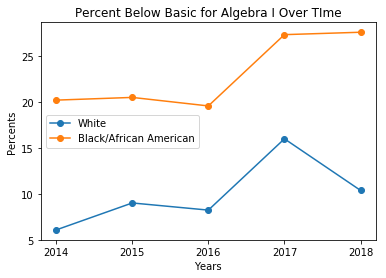

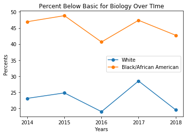

```python
black_algebra_data_18 = []
white_algebra_data_18 = []

black_algebra_data_17 = []
white_algebra_data_17 = []

black_algebra_data_16 = []
white_algebra_data_16 = []

black_algebra_data_15 = []
white_algebra_data_15 = []

black_algebra_data_14 = []
white_algebra_data_14 = []


#2018 Scores
for i, x in df18.iterrows():
    if df18.at[i, 'Group'] == "Black/African American (not Hispanic)":

        if df18.at[i, 'Percent Below Basic'] != 's' and df18.at[i, 'Subject'] == 'Algebra I':
            black_algebra_data_18.append(df18.at[i, 'Percent Below Basic'])

for i, x in df18.iterrows():
    if df18.at[i, 'Group'] == "White (not Hispanic)":

        if df18.at[i, 'Percent Below Basic'] != 's' and df18.at[i, 'Subject'] == 'Algebra I':
            white_algebra_data_18.append(df18.at[i, 'Percent Below Basic'])

#2017 Scores
for i, x in df17.iterrows():
    if df17.at[i, 'Group'] == "Black/African American (not Hispanic)":

        if df17.at[i, 'Percent Below Basic'] != 's' and df17.at[i, 'Subject'] == 'Algebra 1':
            black_algebra_data_17.append(df17.at[i, 'Percent Below Basic'])

for i, x in df17.iterrows():
    if df17.at[i, 'Group'] == "White (not Hispanic)":

        if df17.at[i, 'Percent Below Basic'] != 's' and df17.at[i, 'Subject'] == 'Algebra 1':
            white_algebra_data_17.append(df17.at[i, 'Percent Below Basic'])

#2016 Scores
for i, x in df16.iterrows():
    if df16.at[i, 'Group'] == "Black/African American (not Hispanic)":

        if df16.at[i, 'Percent Below Basic'] != 's' and df16.at[i, 'Subject'] == 'Algebra I':
            black_algebra_data_16.append(df16.at[i, 'Percent Below Basic'])

for i, x in df16.iterrows():
    if df16.at[i, 'Group'] == "White (not Hispanic)":

        if df16.at[i, 'Percent Below Basic'] != 's' and df16.at[i, 'Subject'] == 'Algebra I':
            white_algebra_data_16.append(df16.at[i, 'Percent Below Basic'])

#2015 Scores
for i, x in df15.iterrows():
    if df15.at[i, 'Group'] == "Black/African American (not Hispanic)":

        if df15.at[i, 'Percent Below Basic'] != 's' and df15.at[i, 'Subject'] == 'Algebra I':
            black_algebra_data_15.append(df15.at[i, 'Percent Below Basic'])

for i, x in df15.iterrows():
    if df15.at[i, 'Group'] == "White (not Hispanic)":

        if df15.at[i, 'Percent Below Basic'] != 's' and df15.at[i, 'Subject'] == 'Algebra I':
            white_algebra_data_15.append(df15.at[i, 'Percent Below Basic'])

#2014 Scores
for i, x in df14.iterrows():
    if df14.at[i, 'Group'] == "Black/African American (not Hispanic)":

        if df14.at[i, 'Percent Below Basic'] != 's' and df14.at[i, 'Subject'] == 'Algebra 1':
            black_algebra_data_14.append(df14.at[i, 'Percent Below Basic'])

for i, x in df14.iterrows():
    if df14.at[i, 'Group'] == "White (not Hispanic)":

        if df14.at[i, 'Percent Below Basic'] != 's' and df14.at[i, 'Subject'] == 'Algebra 1':
            white_algebra_data_14.append(df14.at[i, 'Percent Below Basic'])



black_algebra_data_18 = list(map(float, black_algebra_data_18))
white_algebra_data_18 = list(map(float, white_algebra_data_18))

black_algebra_data_17 = list(map(float, black_algebra_data_17))
white_algebra_data_17 = list(map(float, white_algebra_data_17))

black_algebra_data_17 = [x * 100 for x in black_algebra_data_17]
white_algebra_data_17 = [x * 100 for x in white_algebra_data_17]

black_algebra_data_16 = list(map(float, black_algebra_data_16))
white_algebra_data_16 = list(map(float, white_algebra_data_16))

black_algebra_data_16 = [x * 100 for x in black_algebra_data_16]
white_algebra_data_16 = [x * 100 for x in white_algebra_data_16]

black_algebra_data_15 = list(map(float, black_algebra_data_15))
white_algebra_data_15 = list(map(float, white_algebra_data_15))

black_algebra_data_15 = [x * 100 for x in black_algebra_data_15]
white_algebra_data_15 = [x * 100 for x in white_algebra_data_15]

black_algebra_data_14 = list(map(float, black_algebra_data_14))
white_algebra_data_14 = list(map(float, white_algebra_data_14))

black_algebra_data_14 = [x * 100 for x in black_algebra_data_14]
white_algebra_data_14 = [x * 100 for x in white_algebra_data_14]

black_avg_18 = mean(black_algebra_data_18)
white_avg_18 = mean(white_algebra_data_18)

black_avg_17 = mean(black_algebra_data_17)
white_avg_17 = mean(white_algebra_data_17)

black_avg_16 = mean(black_algebra_data_16)
white_avg_16 = mean(white_algebra_data_16)

black_avg_15 = mean(black_algebra_data_15)
white_avg_15 = mean(white_algebra_data_15)

black_avg_14 = mean(black_algebra_data_14)
white_avg_14 = mean(white_algebra_data_14)


white_data = [white_avg_14, white_avg_15, white_avg_16, white_avg_17, white_avg_18]
black_data = [black_avg_14, black_avg_15, black_avg_16, black_avg_17, black_avg_18]


x = np.arange(5)
plt.plot(x, white_data, '-o', label='White')
plt.plot(x, black_data, '-o', label='Black/African American')
plt.xticks(x, [2014, 2015, 2016, 2017, 2018])
plt.xlabel('Years')
plt.ylabel('Percents')
plt.title('Percent Below Basic for Algebra I Over TIme')
plt.legend(loc='center left')
plt.show()

black_bio_data_18 = []
white_bio_data_18 = []

black_bio_data_17 = []
white_bio_data_17 = []

black_bio_data_16 = []
white_bio_data_16 = []

black_bio_data_15 = []
white_bio_data_15 = []

black_bio_data_14 = []
white_bio_data_14 = []


#2018 Scores
for i, x in df18.iterrows():
    if df18.at[i, 'Group'] == "Black/African American (not Hispanic)":

        if df18.at[i, 'Percent Below Basic'] != 's' and df18.at[i, 'Subject'] == 'Biology':
            black_bio_data_18.append(df18.at[i, 'Percent Below Basic'])

for i, x in df18.iterrows():
    if df18.at[i, 'Group'] == "White (not Hispanic)":

        if df18.at[i, 'Percent Below Basic'] != 's' and df18.at[i, 'Subject'] == 'Biology':
            white_bio_data_18.append(df18.at[i, 'Percent Below Basic'])

#2017 Scores
for i, x in df17.iterrows():
    if df17.at[i, 'Group'] == "Black/African American (not Hispanic)":

        if df17.at[i, 'Percent Below Basic'] != 's' and df17.at[i, 'Subject'] == 'Biology':
            black_bio_data_17.append(df17.at[i, 'Percent Below Basic'])

for i, x in df17.iterrows():
    if df17.at[i, 'Group'] == "White (not Hispanic)":

        if df17.at[i, 'Percent Below Basic'] != 's' and df17.at[i, 'Subject'] == 'Biology':
            white_bio_data_17.append(df17.at[i, 'Percent Below Basic'])

#2016 Scores
for i, x in df16.iterrows():
    if df16.at[i, 'Group'] == "Black/African American (not Hispanic)":

        if df16.at[i, 'Percent Below Basic'] != 's' and df16.at[i, 'Subject'] == 'Biology':
            black_bio_data_16.append(df16.at[i, 'Percent Below Basic'])

for i, x in df16.iterrows():
    if df16.at[i, 'Group'] == "White (not Hispanic)":

        if df16.at[i, 'Percent Below Basic'] != 's' and df16.at[i, 'Subject'] == 'Biology':
            white_bio_data_16.append(df16.at[i, 'Percent Below Basic'])

#2015 Scores
for i, x in df15.iterrows():
    if df15.at[i, 'Group'] == "Black/African American (not Hispanic)":

        if df15.at[i, 'Percent Below Basic'] != 's' and df15.at[i, 'Subject'] == 'Biology':
            black_bio_data_15.append(df15.at[i, 'Percent Below Basic'])

for i, x in df15.iterrows():
    if df15.at[i, 'Group'] == "White (not Hispanic)":

        if df15.at[i, 'Percent Below Basic'] != 's' and df15.at[i, 'Subject'] == 'Biology':
            white_bio_data_15.append(df15.at[i, 'Percent Below Basic'])

#2014 Scores
for i, x in df14.iterrows():
    if df14.at[i, 'Group'] == "Black/African American (not Hispanic)":

        if df14.at[i, 'Percent Below Basic'] != 's' and df14.at[i, 'Subject'] == 'Biology':
            black_bio_data_14.append(df14.at[i, 'Percent Below Basic'])

for i, x in df14.iterrows():
    if df14.at[i, 'Group'] == "White (not Hispanic)":

        if df14.at[i, 'Percent Below Basic'] != 's' and df14.at[i, 'Subject'] == 'Biology':
            white_bio_data_14.append(df14.at[i, 'Percent Below Basic'])



black_bio_data_18 = list(map(float, black_bio_data_18))
white_bio_data_18 = list(map(float, white_bio_data_18))

black_bio_data_17 = list(map(float, black_bio_data_17))
white_bio_data_17 = list(map(float, white_bio_data_17))

black_bio_data_17 = [x * 100 for x in black_bio_data_17]
white_bio_data_17 = [x * 100 for x in white_bio_data_17]

black_bio_data_16 = list(map(float, black_bio_data_16))
white_bio_data_16 = list(map(float, white_bio_data_16))

black_bio_data_16 = [x * 100 for x in black_bio_data_16]
white_bio_data_16 = [x * 100 for x in white_bio_data_16]

black_bio_data_15 = list(map(float, black_bio_data_15))
white_bio_data_15 = list(map(float, white_bio_data_15))

black_bio_data_15 = [x * 100 for x in black_bio_data_15]
white_bio_data_15 = [x * 100 for x in white_bio_data_15]

black_bio_data_14 = list(map(float, black_bio_data_14))
white_bio_data_14 = list(map(float, white_bio_data_14))

black_bio_data_14 = [x * 100 for x in black_bio_data_14]
white_bio_data_14 = [x * 100 for x in white_bio_data_14]

black_avg_18 = mean(black_bio_data_18)
white_avg_18 = mean(white_bio_data_18)

black_avg_17 = mean(black_bio_data_17)
white_avg_17 = mean(white_bio_data_17)

black_avg_16 = mean(black_bio_data_16)
white_avg_16 = mean(white_bio_data_16)

black_avg_15 = mean(black_bio_data_15)
white_avg_15 = mean(white_bio_data_15)

black_avg_14 = mean(black_bio_data_14)
white_avg_14 = mean(white_bio_data_14)


white_data = [white_avg_14, white_avg_15, white_avg_16, white_avg_17, white_avg_18]
black_data = [black_avg_14, black_avg_15, black_avg_16, black_avg_17, black_avg_18]

x = np.arange(5)
plt.plot(x, white_data, '-o', label='White')
plt.plot(x, black_data, '-o', label='Black/African American')
plt.xticks(x, [2014, 2015, 2016, 2017, 2018])
plt.xlabel('Years')
plt.ylabel('Percents')
plt.title('Percent Below Basic for Biology Over TIme')
plt.legend(loc='center right')
plt.show()
```

# Trend over the past 5 years for scoring Below Basic

Looking at the resulting graphs, a much higher percent of Black Students are definitely receiving scores of Below Basic in both the Algebra I and Biology exams. There does appear to be some fluctuation in terms of the perceentage of students who are receiving these scores, but nonetheless are still extremely higher than that of White students.

# Analysis and Machine Learning

Now that we have a good idea of what the current year and past years have looked like, the next part in the data lifecycle is to make a predictive model for the years to come. Utilizing the data that we have gathered, we can make a prediction on how students will perform in future exams.

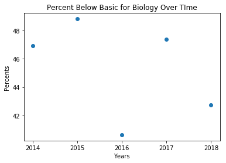

```python
white_data = [white_avg_14, white_avg_15, white_avg_16, white_avg_17, white_avg_18]
black_data = [black_avg_14, black_avg_15, black_avg_16, black_avg_17, black_avg_18]
x = np.arange(5)
years = [2014, 2015, 2016, 2017, 2018]
#plt.plot(x, white_data, '-o', label='White')
plt.plot(x, black_data, 'o', label='Black/African American')
plt.xticks(x, years)
plt.xlabel('Years')
plt.ylabel('Percents')
plt.title('Percent Below Basic for Biology Over TIme')
#plt.legend(loc='center right')
plt.show()
```

Judging by this graph, there does not seem to be much correlation between points. This is a good warning that we may not be able to use this data as a predictive measure for the future.

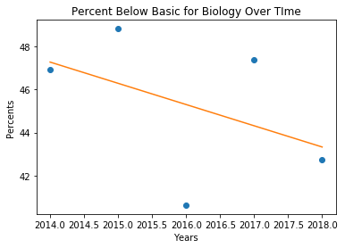

```python
white_data = [white_avg_14, white_avg_15, white_avg_16, white_avg_17, white_avg_18]
black_data = [black_avg_14, black_avg_15, black_avg_16, black_avg_17, black_avg_18]
x = np.arange(5)
years = [2014, 2015, 2016, 2017, 2018]
#plt.plot(x, white_data, '-o', label='White')
plt.plot(years, black_data, 'o', label='Black/African American')

years_ = []

for y in years:
    years_.append([y])

clf = linear_model.LinearRegression()
clf.fit(years_, black_data)
predicted = clf.predict(years_)

plt.plot(years, predicted)


#plt.xticks(x, years)
plt.xlabel('Years')
plt.ylabel('Percents')
plt.title('Percent Below Basic for Biology Over TIme')
#plt.legend(loc='center right')
plt.show()
```

In order to see how effective our fitted regression line is, we can utilize 'clf.score' in order to get a numerical value that represents how strong the relationship is. For more information about regression, visit https://www.surveygizmo.com/resources/blog/regression-analysis/

```python
print(clf.score(years_,black_data))
```

```
0.203159325743
```

~.20 is not very good. It appears that we can not make an accurate prediction based off of the Below basic scores. Let's try the Advanced scoring instead.

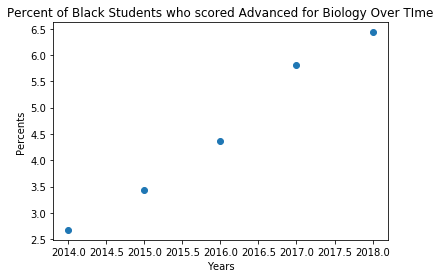

```python
x = np.arange(5)
years = [2014, 2015, 2016, 2017, 2018]
#plt.plot(x, white_data, '-o', label='White')
plt.plot(years, black_ml_data_bio, 'o', label='Black/African American')


#plt.xticks(x, years)
plt.xlabel('Years')
plt.ylabel('Percents')
plt.title('Percent of Black Students who scored Advanced for Biology Over TIme')
#plt.legend(loc='center right')
plt.show()
```

Judging from the points, there is an obvious upward trend which also means it may be a good predictive measure.

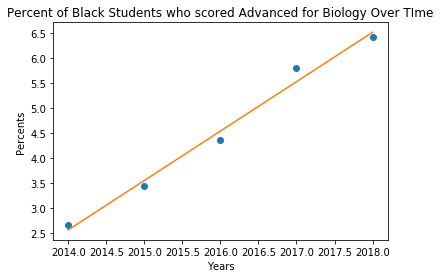

```python
x = np.arange(5)
years = [2014, 2015, 2016, 2017, 2018]
#plt.plot(x, white_data, '-o', label='White')
plt.plot(years, black_ml_data_bio, 'o', label='Black/African American')

years_ = []

for y in years:
    years_.append([y])

clf = linear_model.LinearRegression()
clf.fit(years_, black_ml_data_bio)
predicted = clf.predict(years_)

plt.plot(years, predicted)


#plt.xticks(x, years)
plt.xlabel('Years')
plt.ylabel('Percents')
plt.title('Percent of Black Students who scored Advanced for Biology Over TIme')
#plt.legend(loc='center right')
plt.show()
```

```python
print(clf.score(years_, black_ml_data_bio))
```

```
0.985978797759
```

~.98 is very good! We can definitely make some accurate predictions utilizing this.

```python
clf.predict(2019)
```

```
array([ 7.51261953])
```

According to this prediction, in the year 2019, 7.5 percent of Black students will score advanced on the Biology Exam.

Let's do the same thing for the Algebra I exam.

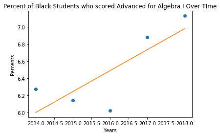

```python
x = np.arange(5)
years = [2014, 2015, 2016, 2017, 2018]
#plt.plot(x, white_data, '-o', label='White')
plt.plot(years, black_ml_data_alg, 'o', label='Black/African American')

years_ = []

for y in years:
    years_.append([y])

clf = linear_model.LinearRegression()
clf.fit(years_, black_ml_data_alg)
predicted = clf.predict(years_)

plt.plot(years, predicted)


#plt.xticks(x, years)
plt.xlabel('Years')
plt.ylabel('Percents')
plt.title('Percent of Black Students who scored Advanced for Algebra I Over TIme')
#plt.legend(loc='center right')
plt.show()
```

```python
print(clf.score(years_, black_ml_data_alg))
```

```
0.632274682394
```

~.63 is not bad, We can't make a prediction with the same confidence as the Biology data, but we can still make a comfortable prediction.

```python
clf.predict(2019)
```

```
array([ 7.22726548])
```

According to the prediction, 7.2 percent of Black students will score Advanced on the Algebra I portion of the Keystone exam.

# Final Comments

As we can see, there is definitely an achievement gap between Black and White students within the Philadelphia School District. It is actually pretty alarming to see how drastic the gap that exists is. The good thing to note, is that using our statistical analysis, we are able to showcase that there is currently an increase in percentage of Black students who are receiving Advanced Scores on the Keystone exam. The predictions for next years exams also reinforce this idea and bring some hope that we will one day close this gap.

One of the useful things about this tutorial, is the ability to apply it to other schools districts given a similar dataset. You could hypotheically find out if this gap exists for any school district! This allows alot of freedom and discovery.